# Sec_GCN_ukbec

Amy Hicks

16/12/2021

This markdown contains an exploration of the secondary coexpression networks from [Sanchez et al., 2021](https://academic.oup.com/bioinformatics/advance-article/doi/10.1093/bioinformatics/btab175/6178279). Four networks were created from frontal cortex tissue data from the **UKBEC dataset** and categorised by the correction or **removal of the effect** of specific cell types, namely **neurons, mature astrocytes, microglia** and **oligodendrocytes**. Several lists of genes of interest were searched within these networks to investigate the effect of cell type on gene co-expression relationships.

```r
# First initialise the datasets/packages to use
CoExp10UKBEC::initDb(mandatory = T)
```

# 1. Gene lists of interest

## 1.1. NSL complex

Firstly, the nine genes encoding the NSL complex will be focused on [(Sheikh et al., 2019)](https://www.ncbi.nlm.nih.gov/pmc/articles/PMC6607013/). These genes encode proteins which make up an **acetyltransferase complex** linked to both nuclear and mitochondrial gene expression.

```r
# Load list
NSL_list <- read.delim(file.path(here::here("data", "Gene_lists", "NSL_list.txt")))
# Add column with gene symbols known to be in UKBEC dataset
NSL_list$UKBEC <- NSL_list$Gene_symbol
NSL_list$UKBEC[NSL_list$UKBEC=="KANSL1"] <- "KIAA1267"
NSL_list$UKBEC[NSL_list$UKBEC=="KAT8"] <- "MYST1"
NSL_list$UKBEC[NSL_list$UKBEC=="KANSL2"] <- "C12orf41"
NSL_list$UKBEC[NSL_list$UKBEC=="KANSL3"] <- "KIAA1310"
# Edit add column with combination of UKBEC symbols and ENSGs
NSL_list$UKBEC_symbol <- as.character(NSL_list$Ensembl_ID)
NSL_list$UKBEC_symbol[NSL_list$UKBEC_symbol=="ENSG00000120071"] <- "KIAA1267"
NSL_list$UKBEC_symbol[NSL_list$UKBEC_symbol=="ENSG00000103510"] <- "MYST1"
NSL_list$UKBEC_symbol[NSL_list$UKBEC_symbol=="ENSG00000139620"] <- "C12orf41"
NSL_list$UKBEC_symbol[NSL_list$UKBEC_symbol=="ENSG00000114982"] <- "KIAA1310"
# Make search list
NSL_ENSG <- as.character(NSL_list$UKBEC_symbol)
```

The number of genes in this list: **9**.

## 1.2. PD mendelian

A list of highly penetrant genes linked to familial forms of Parkinson's disease was obtained from PanelApp [Parkinson disease and complex Parkinsonism version 1.68](https://panelapp.genomicsengland.co.uk/panels/39/), a list collected and validated by a group of experts.

```r
# Load list
PD_mendelian_list <- read.delim(file.path(here::here("data", "Gene_lists", "PD_mendelian_list.txt")))
# Add column with gene symbols known to be in UKBEC dataset
PD_mendelian_list$UKBEC <- as.character(PD_mendelian_list$Gene_symbol)
PD_mendelian_list$UKBEC[PD_mendelian_list$UKBEC=="TUBB4A"] <- "TUBB4"
# Edit add column with combination of UKBEC symbols and ENSGs
PD_mendelian_list$UKBEC_symbol <- as.character(PD_mendelian_list$Ensembl_ID)
PD_mendelian_list$UKBEC_symbol[PD_mendelian_list$UKBEC_symbol=="ENSG00000104833"] <- "TUBB4"
# Make search list
PD_mendelian_ENSG <- as.character(PD_mendelian_list$UKBEC_symbol)
```

The number of genes in this list: **43**.

## 1.3. PD sporadic

A list of less penetrant, more common genes linked to sporadic Parkinson's disease was obtained from the latest GWAS, described as *"Of the genes possibly associated with at least one QTL in public reference datasets and therefore testable via summary-based Mendelian randomisation, the expression or methylation of 64% was significantly associated with a possible causal change in Parkinson's disease risk."*

```r
# Load list
PD_GWAS_list <- read.delim(file.path(here::here("data", "Gene_lists", "PD_GWAS_list.txt")))
# Add column with gene symbols known to be in UKBEC dataset
PD_GWAS_list$UKBEC <- as.character(PD_GWAS_list$Gene_symbol)
#PD_GWAS_list$UKBEC[PD_GWAS_list$UKBEC=="CCAR2"] <- "KIAA1967"
PD_GWAS_list$UKBEC[PD_GWAS_list$UKBEC=="LINC00174"] <- "NCRNA00174"
PD_GWAS_list$UKBEC[PD_GWAS_list$UKBEC=="MALSU1"] <- "C7orf30"
#PD_GWAS_list$UKBEC[PD_GWAS_list$UKBEC=="PGF"] <- "PIGF"
PD_GWAS_list$UKBEC[PD_GWAS_list$UKBEC=="PPIP5K2"] <- "HISPPD1"
#PD_GWAS_list$UKBEC[PD_GWAS_list$UKBEC=="RAB29"] <- "RAB7L1"
#PD_GWAS_list$UKBEC[PD_GWAS_list$UKBEC=="RETREG3"] <- "FAM134C"
#PD_GWAS_list$UKBEC[PD_GWAS_list$UKBEC=="SGF29"] <- "CCDC101"
PD_GWAS_list$UKBEC[PD_GWAS_list$UKBEC=="TMEM248"] <- "C7orf42"
PD_GWAS_list$UKBEC[PD_GWAS_list$UKBEC=="ZKSCAN8"] <- "ZNF192"
PD_GWAS_list$UKBEC[PD_GWAS_list$UKBEC=="ZNF192P1"] <- "ZNF389"
# Edit add column with combination of UKBEC symbols and ENSGs
PD_GWAS_list$UKBEC_symbol <- as.character(PD_GWAS_list$Ensembl_ID)
#PD_GWAS_list$UKBEC_symbol[PD_GWAS_list$UKBEC_symbol=="ENSG00000158941"] <- "KIAA1967"
PD_GWAS_list$UKBEC_symbol[PD_GWAS_list$UKBEC_symbol=="ENSG00000179406"] <- "NCRNA00174"
PD_GWAS_list$UKBEC_symbol[PD_GWAS_list$UKBEC_symbol=="ENSG00000156928"] <- "C7orf30"
#PD_GWAS_list$UKBEC_symbol[PD_GWAS_list$UKBEC_symbol=="ENSG00000119630"] <- "PIGF"
PD_GWAS_list$UKBEC_symbol[PD_GWAS_list$UKBEC_symbol=="ENSG00000145725"] <- "HISPPD1"
#PD_GWAS_list$UKBEC_symbol[PD_GWAS_list$UKBEC_symbol=="ENSG00000117280"] <- "RAB7L1"
#PD_GWAS_list$UKBEC_symbol[PD_GWAS_list$UKBEC_symbol=="ENSG00000141699"] <- "FAM134C"
#PD_GWAS_list$UKBEC_symbol[PD_GWAS_list$UKBEC_symbol=="ENSG00000176476"] <- "CCDC101"
PD_GWAS_list$UKBEC_symbol[PD_GWAS_list$UKBEC_symbol=="ENSG00000106609"] <- "C7orf42"
PD_GWAS_list$UKBEC_symbol[PD_GWAS_list$UKBEC_symbol=="ENSG00000198315"] <- "ZNF192"
PD_GWAS_list$UKBEC_symbol[PD_GWAS_list$UKBEC_symbol=="ENSG00000226314"] <- "ZNF389"
# Make search list
PD_GWAS_ENSG <- as.character(PD_GWAS_list$UKBEC_symbol)
```

The number of genes in this list: **150**.

# 2. Useful info from primary network

Some information from the primary gene co-expression network was compared to results from secondary gene co-expression networks.

```r
# Load enrichments from primary network
ukbec_net <- readRDS(file.path(here::here("data", "CoExp_source", "netFCTX.12.signed.it.20.rds_cor_pca.rds")))
ukbec_enrich <- as.data.frame(getModulesEnrichment(ukbec_net,
                                                   markers.path = file.path(here::here("data", "GMSCA_source", "markers"))))
# Search NSL genes in primary network
NSL_report_uk <- reportOnGenes(tissue = "FCTX", genes = NSL_ENSG, which.one = "10UKBEC")
NSL_rep_uk <- NSL_report_uk$report
NSL_mods <- as.character(unique(NSL_rep_uk$module))
ukbec_enrich_NSL <- dplyr::select(ukbec_enrich, one_of(NSL_mods))
```

# 3. Neuron network

The overall structure of the network was first examined.

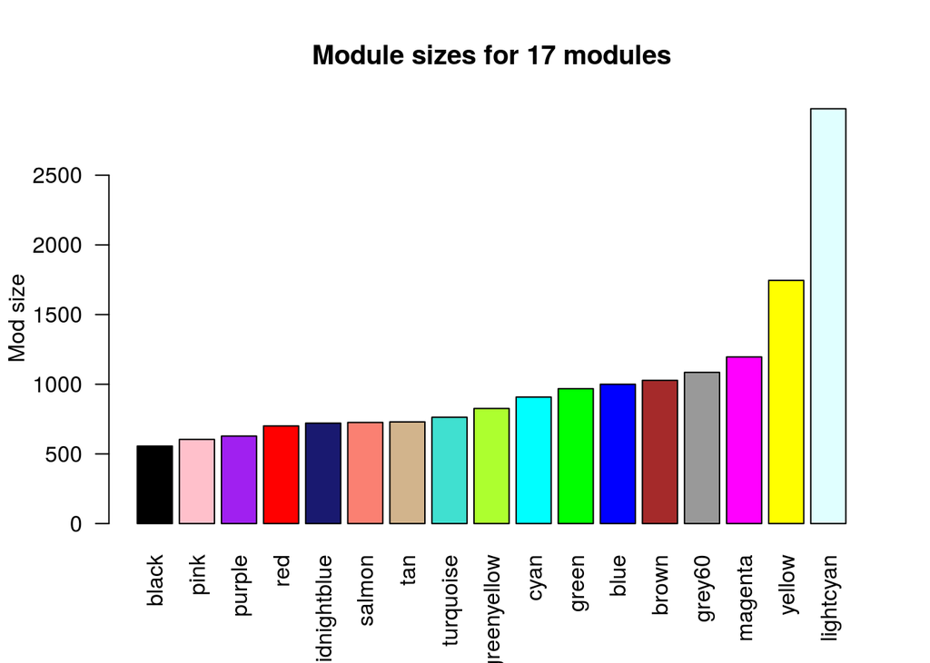

```r
# Load network
N_net = readRDS(file.path(here::here("data", "Networks", "netFCTX.12.signed.it.20.rds.No.N.rds")))
# Plot sizes of modules making up the network
CoExpNets::plotModSizes(tissue = N_net, which.one = "new")
```

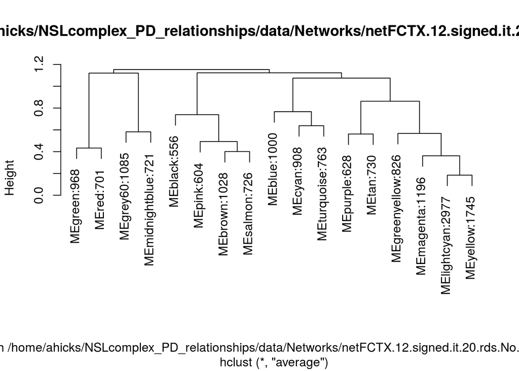

```r
# Obtain eigengenes for each module
N_net.name <- file.path(here::here("data", "Networks", "netFCTX.12.signed.it.20.rds.No.N.rds"))
N_egs <- CoExpNets::getNetworkEigengenes(tissue = N_net.name, which.one = "new")
# Plot eigengene clustering
CoExpNets::plotEGClustering(tissue = N_net.name, which.one = "new")
```

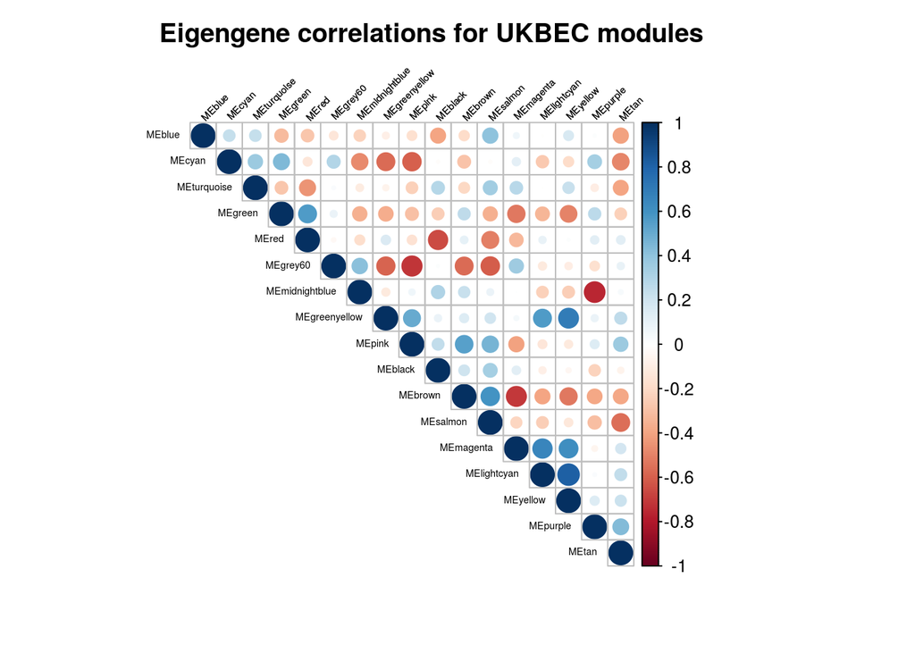

```r
# Plot correlation between modules
corrplot(cor(N_egs), tl.srt = 45,
         tl.col = "black",
         type = "upper",
         tl.cex = 0.45,
         order = "hclust",
         title = paste0("Eigengene correlations for UKBEC modules"),
         mar = c(3, 2, 2.5, 4))
```

## 3.1. Searching gene list

### NSL genes

First the genes encoding the NSL complex were searched.

```r
# Search genes in network
N_NSL_mod <- as.data.frame(CoExpNets::reportOnFETGenes(tissue = N_net.name, genes = NSL_ENSG, which.one = "new", net = NULL))
N_NSL_mod <- tibble::rownames_to_column(N_NSL_mod, "ENSG")
N_NSL_mod <- dplyr::select(N_NSL_mod, ENSG, module, p.val.mods)
N_NSL_mod$Gene <- N_NSL_mod$ENSG
# Add gene symbols
for (i in NSL_list$UKBEC_symbol) {
  loc <- match(i, NSL_list$UKBEC_symbol)
  N_NSL_mod$Gene[N_NSL_mod$Gene== i] <- NSL_list$Gene_symbol[loc]
}
# Get module membership
N_MM <- as.data.frame(N_net$MM)
colnames(N_MM)<- "MM"
N_MM <- rownames_to_column(N_MM, "ENSG")
N_MM$MM <- signif(N_MM$MM, 4)
# Add MM to table
N_NSL_mod$MM <- N_NSL_mod$ENSG
for (i in N_MM$ENSG) {
  loc <- match(i, N_MM$ENSG)
  N_NSL_mod$MM[N_NSL_mod$MM== i] <- N_MM$MM[loc]
}
# Reorder table
N_NSL_mod <- N_NSL_mod[,c(4,1,5,2,3)]
N_NSL_mod <- dplyr::arrange(N_NSL_mod, p.val.mods)
# Store NSL enriched modules
N_NSL_modules <- as.character(unique(N_NSL_mod$module))
N_NSL_modules <- N_NSL_modules[N_NSL_modules!="void"]
# Print result
N_NSL_mod
```

| Gene | ENSG | MM | module | p.val.mods |
| --- | --- | --- | --- | --- |
| HCFC1 | ENSG00000172534 | 0.8684 | grey60 | 0.0009052 |
| KANSL1 | KIAA1267 | 0.6606 | grey60 | 0.0009052 |
| KAT8 | MYST1 | 0.4975 | grey60 | 0.0009052 |
| MCRS1 | ENSG00000187778 | 0.5499 | grey60 | 0.0009052 |
| KANSL2 | C12orf41 | 0.5189 | purple | 0.03233 |
| OGT | ENSG00000147162 | 0.6295 | purple | 0.03233 |
| KANSL3 | KIAA1310 | 0.5091 | midnightblue | 0.2907 |
| PHF20 | ENSG00000025293 | 0.6828 | cyan | 0.3527 |
| WDR5 | ENSG00000196363 | ENSG00000196363 | void | 1 |

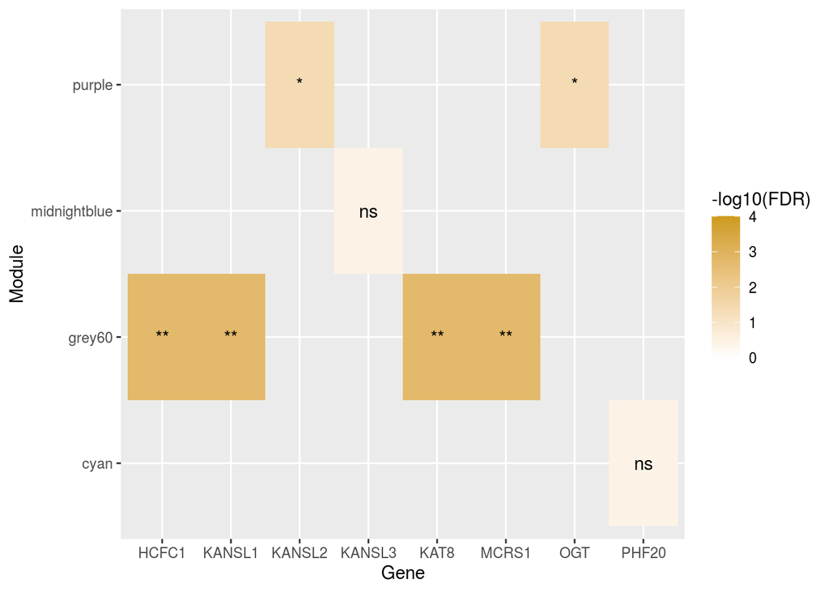

```r
# Remove void
N_NSL_mod <- dplyr::filter(N_NSL_mod, module !="void")
# Format dataframe for figure
N_NSL_mod$FDR <- p.adjust(N_NSL_mod$p.val.mods, method = "fdr")
names(N_NSL_mod)[names(N_NSL_mod)=="p.val.mods"] <- "p.val"
names(N_NSL_mod)[names(N_NSL_mod)=="module"] <- "Module"
N_NSL_mod$p.val <- as.numeric(N_NSL_mod$p.val)
N_NSL_mod <- dplyr::arrange(N_NSL_mod, Module)
N_NSL_mod$`-log10(p.val)` <- -log10(N_NSL_mod$p.val)
N_NSL_mod$`-log10(FDR)` <- -log10(N_NSL_mod$FDR)
# Produce plot
source(file.path(here::here("scripts", "CoExp_functions.R")))
ggplot(N_NSL_mod, aes(Gene, Module)) +
  geom_tile(aes(fill = `-log10(FDR)`)) +
  geom_text(aes(label = signif.num(FDR))) +
  scale_fill_gradient(low = "white", high = "goldenrod3", limits = c(0,4)) +
  labs(y = "Module", x = "Gene")
```

The total number of genes in the output table was **8**, indicating there were **1** genes missing from the search. These genes appeared in 4 modules, each of which was examined for **enrichment** of cell type specific markers.

```r
# Load cell type markers enriched for each module
N_mod_enrich <- as.data.frame(getModulesEnrichment(N_net, markers.path = file.path(here::here("data", "GMSCA_source", "markers"))))
# Filter enrichments for NSL modules
N_mod_enrich_NSL <- dplyr::select(N_mod_enrich, one_of(N_NSL_modules))
```

The modules containing NSL genes showed **no significant enrichment** for **any cell types**.

### PD mendelian genes

The results tables for the mendelian PD gene list were filtered for the 4 modules containing NSL genes.

```r
# Search genes in network
N_PD_mendelian_mod <- as.data.frame(CoExpNets::reportOnFETGenes(tissue = N_net.name, genes = PD_mendelian_ENSG, which.one = "new", net = NULL))
N_PD_mendelian_mod <- tibble::rownames_to_column(N_PD_mendelian_mod, "ENSG")
N_PD_mendelian_mod <- dplyr::select(N_PD_mendelian_mod, ENSG, module, p.val.mods)
N_PD_mendelian_mod$Gene <- N_PD_mendelian_mod$ENSG
# Add gene symbols
for (i in PD_mendelian_list$UKBEC_symbol) {
  loc <- match(i, PD_mendelian_list$UKBEC_symbol)
  N_PD_mendelian_mod$Gene[N_PD_mendelian_mod$Gene== i] <- PD_mendelian_list$Gene_symbol[loc]
}
# Add MM to table
N_PD_mendelian_mod$MM <- N_PD_mendelian_mod$ENSG
for (i in N_MM$ENSG) {
  loc <- match(i, N_MM$ENSG)
  N_PD_mendelian_mod$MM[N_PD_mendelian_mod$MM== i] <- N_MM$MM[loc]
}
# Reorder table
N_PD_mendelian_mod <- N_PD_mendelian_mod[,c(4,1,5,2,3)]
N_PD_mendelian_mod <- dplyr::arrange(N_PD_mendelian_mod, p.val.mods)
# Filter for NSL enriched modules
N_PD_mendelian_mod1 <- filter(N_PD_mendelian_mod, module %in% N_NSL_modules)
# Print result
N_PD_mendelian_mod1
```

| Gene | ENSG | MM | module | p.val.mods |
| --- | --- | --- | --- | --- |
| ATP13A2 | ENSG00000159363 | 0.514 | midnightblue | 0.006902 |
| DCTN1 | ENSG00000204843 | 0.6385 | midnightblue | 0.006902 |
| HTT | ENSG00000197386 | 0.6799 | midnightblue | 0.006902 |
| SLC39A14 | ENSG00000104635 | 0.3136 | midnightblue | 0.006902 |
| SPR | ENSG00000116096 | 0.2448 | midnightblue | 0.006902 |
| TBP | ENSG00000112592 | 0.4864 | midnightblue | 0.006902 |
| ATN1 | ENSG00000111676 | 0.834 | grey60 | 0.1146 |
| ATXN2 | ENSG00000204842 | 0.6736 | grey60 | 0.1146 |
| GRN | ENSG00000030582 | 0.6616 | grey60 | 0.1146 |
| OPA3 | ENSG00000125741 | 0.5171 | grey60 | 0.1146 |

[output cut: 3 more lines]

The number of genes in the output table was **43**, indicating there were **0** genes missing from the search.

### PD sporadic genes

The results tables for the sporadic PD gene list were filtered for the 4 modules containing NSL genes.

```r
# Search genes in network
N_PD_GWAS_mod <- as.data.frame(CoExpNets::reportOnFETGenes(tissue = N_net.name, genes = PD_GWAS_ENSG, which.one = "new", net = NULL))
N_PD_GWAS_mod <- tibble::rownames_to_column(N_PD_GWAS_mod, "ENSG")
N_PD_GWAS_mod <- dplyr::select(N_PD_GWAS_mod, ENSG, module, p.val.mods)
N_PD_GWAS_mod$Gene <- N_PD_GWAS_mod$ENSG
# Add gene symbols
for (i in PD_GWAS_list$Ensembl_ID) {
  loc <- match(i, PD_GWAS_list$Ensembl_ID)
  N_PD_GWAS_mod$Gene[N_PD_GWAS_mod$Gene== i] <- PD_GWAS_list$Gene_symbol[loc]
}
# Add MM to table
N_PD_GWAS_mod$MM <- N_PD_GWAS_mod$ENSG
for (i in N_MM$ENSG) {
  loc <- match(i, N_MM$ENSG)
  N_PD_GWAS_mod$MM[N_PD_GWAS_mod$MM== i] <- N_MM$MM[loc]
}
# Reorder table
N_PD_GWAS_mod <- N_PD_GWAS_mod[,c(4,1,5,2,3)]
N_PD_GWAS_mod <- dplyr::arrange(N_PD_GWAS_mod, p.val.mods)
# Filter for NSL enriched modules
N_PD_GWAS_mod1 <- filter(N_PD_GWAS_mod, module %in% N_NSL_modules)
# Print result
N_PD_GWAS_mod1
```

| Gene | ENSG | MM | module | p.val.mods |
| --- | --- | --- | --- | --- |
| DYRK1A | ENSG00000157540 | 0.2832 | grey60 | 0.005449 |
| FBRSL1 | ENSG00000112787 | 0.7136 | grey60 | 0.005449 |
| GRN | ENSG00000030582 | 0.6616 | grey60 | 0.005449 |
| HSD17B1 | ENSG00000108786 | 0.3245 | grey60 | 0.005449 |
| PGS1 | ENSG00000087157 | 0.4225 | grey60 | 0.005449 |
| POLR2A | ENSG00000181222 | 0.479 | grey60 | 0.005449 |
| PRSS3 | ENSG00000010438 | 0.5943 | grey60 | 0.005449 |
| RETREG3 | ENSG00000141699 | 0.4325 | grey60 | 0.005449 |
| SATB1 | ENSG00000182568 | 0.175 | grey60 | 0.005449 |
| SETD1A | ENSG00000099381 | 0.8399 | grey60 | 0.005449 |

[output cut: 22 more lines]

The number of genes in the output table was **150**, indicating there were **0** genes missing from the search.

## 3.2. Summary

The **frequency** of **genes** within each gene **list** apppearing in each of the **4 NSL enriched modules** was calculated.

```r
# Collate module results into one table
N1 <- N_PD_mendelian_mod1['module']
N1['Gene_list'] <- "PD_mendelian"
N2 <- N_PD_GWAS_mod1['module']
N2['Gene_list'] <- "PD_GWAS"
N_mods_list <- do.call(rbind, list(N1, N2))
# Display as frequency of each module within each list
N_mod_freq <- with(N_mods_list, table(module, Gene_list))
N_mod_freq <- as.data.frame.matrix(N_mod_freq)
N_mod_freq <- dplyr::filter(N_mod_freq, rownames(N_mod_freq) %in% N_NSL_modules)
N_mod_freq <- N_mod_freq[c(2, 3, 4, 1),]
```

```r
knitr::kable(N_mod_freq)
```

|  | PD_GWAS | PD_mendelian |
| --- | --- | --- |
| grey60 | 16 | 5 |
| midnightblue | 9 | 6 |
| purple | 2 | 2 |
| cyan | 5 | 0 |

The **significance** of the **enrichments** of each **gene list** within each of the **4 NSL enriched modules** was also calculated. P-values were **FDR-corrected** before summarising.

```r
# FDR correct p values
N_PD_mendelian_mod1$FDR <- p.adjust(N_PD_mendelian_mod1$p.val.mods, method = "fdr")
N_PD_GWAS_mod1$FDR <- p.adjust(N_PD_GWAS_mod1$p.val.mods, method = "fdr")
```

```r
knitr::kable(N_TF)
```

|  | PD_GWAS | PD_mendelian |
| --- | --- | --- |
| grey60 | 0.0108980 | 0.1354364 |
| midnightblue | 0.1031168 | 0.0149543 |
| purple | 0.9462000 | 0.4456000 |
| cyan | 0.8504533 | NA |

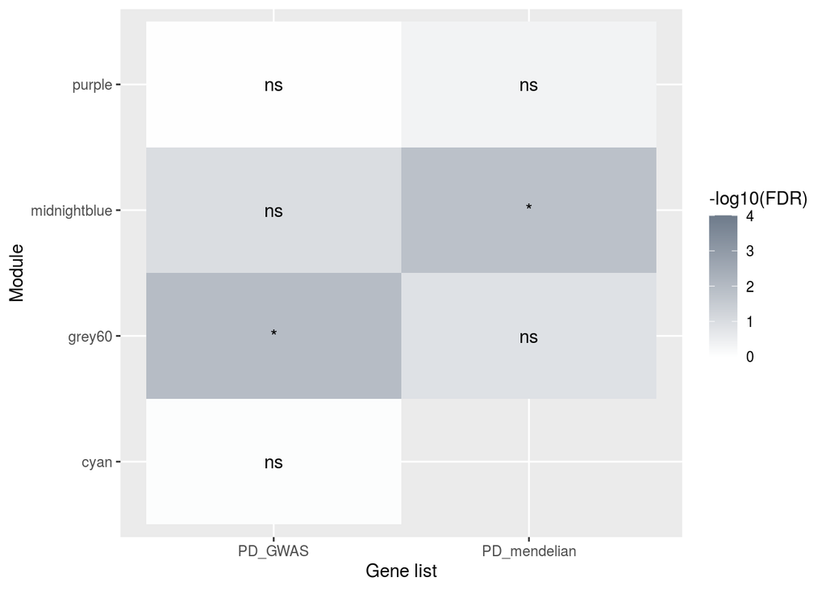

```r
# Filter repeats
N_melt_summ <- N_pvals_list %>%
  dplyr::distinct()
# Prep for figure
N_melt_summ$Module <- as.character(N_melt_summ$Module)
N_melt_summ$Gene_list <- as.character(N_melt_summ$Gene_list)
N_melt_summ$FDR <- as.numeric(N_melt_summ$FDR)
N_melt_summ$`-log10(FDR)` <- -log10(N_melt_summ$FDR)
N_melt_summ <- dplyr::arrange(N_melt_summ, Module)
# Plot
ggplot(N_melt_summ, aes(Gene_list, Module)) +
  geom_tile(aes(fill = `-log10(FDR)`)) +
  geom_text(aes(label = signif.num(FDR))) +
  scale_fill_gradient(low = "white", high = "lightsteelblue4", limits = c(0,4)) +
  labs(y = "Module", x = "Gene list")
```

# 4. Astrocyte network

The overall structure of the network was first examined.

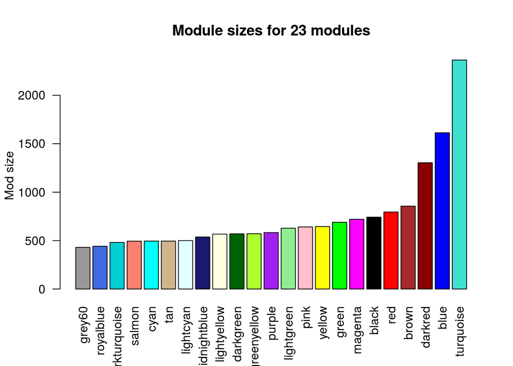

```r
# Load network
MA_net = readRDS(file.path(here::here("data", "Networks", "netFCTX.12.signed.it.20.rds.No.MA.rds")))
# Plot sizes of modules making up the network
CoExpNets::plotModSizes(tissue = MA_net, which.one = "new")
```

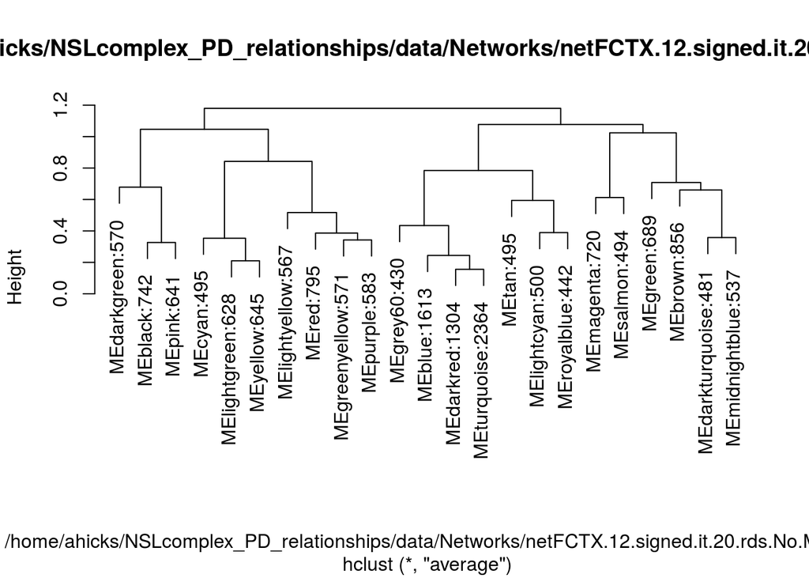

```r
# Obtain eigengenes for each module
MA_net.name <- file.path(here::here("data", "Networks", "netFCTX.12.signed.it.20.rds.No.MA.rds"))
MA_egs <- CoExpNets::getNetworkEigengenes(tissue = MA_net.name, which.one = "new")
# Plot eigengene clustering
CoExpNets::plotEGClustering(tissue = MA_net.name, which.one = "new")
```

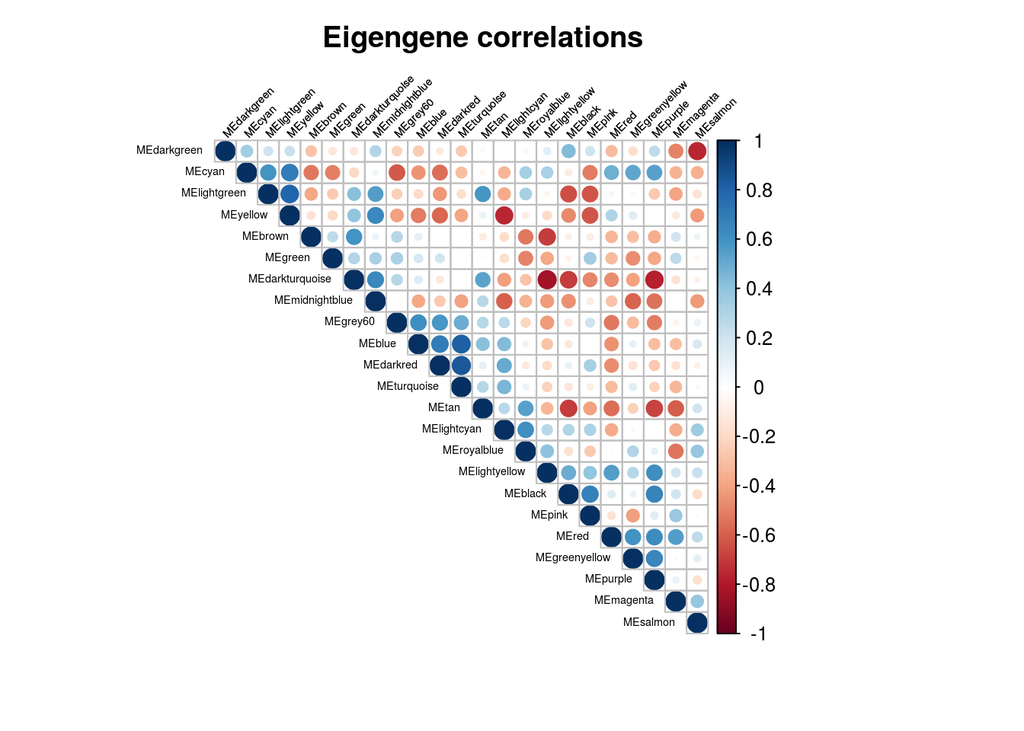

```r
# Plot correlation between modules
corrplot(cor(MA_egs), tl.srt = 45,
         tl.col = "black",
         type = "upper",
         tl.cex = 0.45,
         order = "hclust",
         title = paste0("Eigengene correlations"),
         mar = c(3, 2, 2.5, 4))
```

## 4.1. Searching gene lists

### NSL genes

First the genes encoding the NSL complex were searched.

```r
# Search genes in network
MA_NSL_mod <- as.data.frame(CoExpNets::reportOnFETGenes(tissue = MA_net.name, genes = NSL_ENSG, which.one = "new", net = NULL))
MA_NSL_mod <- tibble::rownames_to_column(MA_NSL_mod, "ENSG")
MA_NSL_mod <- dplyr::select(MA_NSL_mod, ENSG, module, p.val.mods)
MA_NSL_mod$Gene <- MA_NSL_mod$ENSG
# Add gene symbols
for (i in NSL_list$UKBEC_symbol) {
  loc <- match(i, NSL_list$UKBEC_symbol)
  MA_NSL_mod$Gene[MA_NSL_mod$Gene== i] <- NSL_list$Gene_symbol[loc]
}
# Get module membership
#MA_MM <- as.data.frame(MA_net$MM)
#colnames(MA_MM)<- "MM"
#MA_MM <- rownames_to_column(MA_MM, "ENSG")
#MA_MM$MM <- signif(MA_MM$MM, 4)
# Add MM to table
#MA_NSL_mod$MM <- MA_NSL_mod$ENSG
#for (i in MA_MM$ENSG) {
#  loc <- match(i, MA_MM$ENSG)
#  MA_NSL_mod$MM[MA_NSL_mod$MM== i] <- MA_MM$MM[loc]
#}
# Reorder table
MA_NSL_mod <- MA_NSL_mod[,c(4,1,2,3)]
MA_NSL_mod <- dplyr::arrange(MA_NSL_mod, p.val.mods)
# Store NSL enriched modules
MA_NSL_modules <- as.character(unique(MA_NSL_mod$module))
MA_NSL_modules <- MA_NSL_modules[!MA_NSL_modules =="void"]
# Print result
MA_NSL_mod
```

| Gene | ENSG | module | p.val.mods |
| --- | --- | --- | --- |
| HCFC1 | ENSG00000172534 | black | 0.000211 |
| KANSL1 | KIAA1267 | black | 0.000211 |
| KAT8 | MYST1 | black | 0.000211 |
| MCRS1 | ENSG00000187778 | black | 0.000211 |
| OGT | ENSG00000147162 | royalblue | 0.1884 |
| KANSL2 | C12orf41 | salmon | 0.2084 |
| KANSL3 | KIAA1310 | darkgreen | 0.2368 |
| PHF20 | ENSG00000025293 | magenta | 0.2903 |
| WDR5 | ENSG00000196363 | void | 1 |

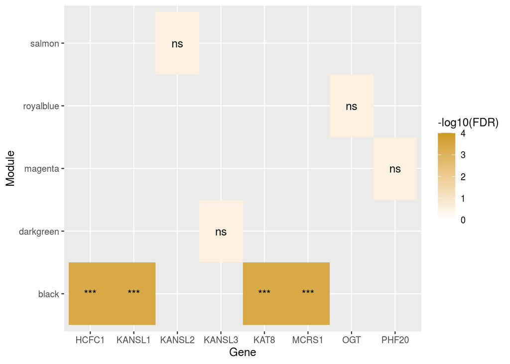

```r
# Remove void
MA_NSL_mod <- dplyr::filter(MA_NSL_mod, module !="void")
# Format dataframe for figure
MA_NSL_mod$FDR <- p.adjust(MA_NSL_mod$p.val.mods, method = "fdr")
names(MA_NSL_mod)[names(MA_NSL_mod)=="p.val.mods"] <- "p.val"
names(MA_NSL_mod)[names(MA_NSL_mod)=="module"] <- "Module"
MA_NSL_mod$p.val <- as.numeric(MA_NSL_mod$p.val)
MA_NSL_mod <- dplyr::arrange(MA_NSL_mod, Module)
MA_NSL_mod$`-log10(p.val)` <- -log10(MA_NSL_mod$p.val)
MA_NSL_mod$`-log10(FDR)` <- -log10(MA_NSL_mod$FDR)
# Produce plot
ggplot(MA_NSL_mod, aes(Gene, Module)) +
  geom_tile(aes(fill = `-log10(FDR)`)) +
  geom_text(aes(label = signif.num(FDR))) +
  scale_fill_gradient(low = "white", high = "goldenrod3", limits = c(0,4)) +
  labs(y = "Module", x = "Gene")
```

The number of genes in the output table was **8**, indicating there were **1** genes missing from the search. These genes appeared in 5 modules, each of which was examined for **enrichment** of cell type specific markers.

```r
# Load cell type markers enriched for each module
MA_mod_enrich <- as.data.frame(getModulesEnrichment(MA_net,
                                                    markers.path = file.path(here::here("data", "GMSCA_source", "markers"))))
# Filter enrichments for NSL modules
MA_mod_enrich_NSL <- dplyr::select(MA_mod_enrich, one_of(MA_NSL_modules))
```

The modules containing NSL genes showed **no significant enrichment** for **any cell types**.

### PD mendelian genes

The results tables for the mendelian PD gene list were filtered for the 5 modules containing NSL genes.

```r
# Search genes in network
MA_PD_mendelian_mod <- as.data.frame(CoExpNets::reportOnFETGenes(tissue = MA_net.name, genes = PD_mendelian_ENSG, which.one = "new", net = NULL))
MA_PD_mendelian_mod <- tibble::rownames_to_column(MA_PD_mendelian_mod, "ENSG")
MA_PD_mendelian_mod <- dplyr::select(MA_PD_mendelian_mod, ENSG, module, p.val.mods)
MA_PD_mendelian_mod$Gene <- MA_PD_mendelian_mod$ENSG
# Add gene symbols
for (i in PD_mendelian_list$UKBEC_symbol) {
  loc <- match(i, PD_mendelian_list$UKBEC_symbol)
  MA_PD_mendelian_mod$Gene[MA_PD_mendelian_mod$Gene== i] <- PD_mendelian_list$Gene_symbol[loc]
}
# Add MM to table
#MA_PD_mendelian_mod$MM <- MA_PD_mendelian_mod$ENSG
#for (i in MA_MM$ENSG) {
#  loc <- match(i, MA_MM$ENSG)
#  MA_PD_mendelian_mod$MM[MA_PD_mendelian_mod$MM== i] <- MA_MM$MM[loc]
#}
# Reorder table
MA_PD_mendelian_mod <- MA_PD_mendelian_mod[,c(4,1,2,3)]
MA_PD_mendelian_mod <- dplyr::arrange(MA_PD_mendelian_mod, p.val.mods)
# Filter for NSL enriched modules
MA_PD_mendelian_mod1 <- filter(MA_PD_mendelian_mod, module %in% MA_NSL_modules)
# Print result
MA_PD_mendelian_mod1
```

| Gene | ENSG | module | p.val.mods |
| --- | --- | --- | --- |
| ATN1 | ENSG00000111676 | black | 0.03087 |
| ATXN2 | ENSG00000204842 | black | 0.03087 |
| GRN | ENSG00000030582 | black | 0.03087 |
| OPA3 | ENSG00000125741 | black | 0.03087 |
| TUBB4A | TUBB4 | black | 0.03087 |
| DCTN1 | ENSG00000204843 | darkgreen | 0.1545 |
| HTT | ENSG00000197386 | darkgreen | 0.1545 |
| TBP | ENSG00000112592 | darkgreen | 0.1545 |
| SPG11 | ENSG00000104133 | salmon | 0.6985 |

The number of genes in the output table was **43**, indicating there were **0** genes missing from the search.

### PD sporadic genes

The results tables for the sporadic PD gene list were filtered for the 5 modules containing NSL genes.

```r
# Search genes in network
MA_PD_GWAS_mod <- as.data.frame(CoExpNets::reportOnFETGenes(tissue = MA_net.name, genes = PD_GWAS_ENSG, which.one = "new", net = NULL))
MA_PD_GWAS_mod <- tibble::rownames_to_column(MA_PD_GWAS_mod, "ENSG")
MA_PD_GWAS_mod <- dplyr::select(MA_PD_GWAS_mod, ENSG, module, p.val.mods)
MA_PD_GWAS_mod$Gene <- MA_PD_GWAS_mod$ENSG
# Add gene symbols
for (i in PD_GWAS_list$UKBEC_symbol) {
  loc <- match(i, PD_GWAS_list$UKBEC_symbol)
  MA_PD_GWAS_mod$Gene[MA_PD_GWAS_mod$Gene== i] <- PD_GWAS_list$Gene_symbol[loc]
}
# Add MM to table
#MA_PD_GWAS_mod$MM <- MA_PD_GWAS_mod$ENSG
#for (i in MA_MM$ENSG) {
#  loc <- match(i, MA_MM$ENSG)
#  MA_PD_GWAS_mod$MM[MA_PD_GWAS_mod$MM== i] <- MA_MM$MM[loc]
#}
# Reorder table
MA_PD_GWAS_mod <- MA_PD_GWAS_mod[,c(4,1,2,3)]
MA_PD_GWAS_mod <- dplyr::arrange(MA_PD_GWAS_mod, p.val.mods)
# Filter for NSL enriched modules
MA_PD_GWAS_mod1 <- filter(MA_PD_GWAS_mod, module %in% MA_NSL_modules)
# Print result
MA_PD_GWAS_mod1
```

| Gene | ENSG | module | p.val.mods |
| --- | --- | --- | --- |
| GRN | ENSG00000030582 | black | 0.01962 |
| HSD17B1 | ENSG00000108786 | black | 0.01962 |
| PGS1 | ENSG00000087157 | black | 0.01962 |
| POLR2A | ENSG00000181222 | black | 0.01962 |
| PRSS3 | ENSG00000010438 | black | 0.01962 |
| RETREG3 | ENSG00000141699 | black | 0.01962 |
| SETD1A | ENSG00000099381 | black | 0.01962 |
| SGF29 | ENSG00000176476 | black | 0.01962 |
| SH2B1 | ENSG00000178188 | black | 0.01962 |
| SPNS1 | ENSG00000169682 | black | 0.01962 |

[output cut: 16 more lines]

The number of genes in the output table was **150**, indicating there were **0** genes missing from the search.

## 4.2. Summary

The **frequency** of **genes** within each gene **list** apppearing in each of the **5 NSL enriched modules** was calculated.

```r
# Collate module results into one table
MA1 <- MA_PD_mendelian_mod1['module']
MA1['Gene_list'] <- "PD_mendelian"
MA2 <- MA_PD_GWAS_mod1['module']
MA2['Gene_list'] <- "PD_GWAS"
MA_mods_list <- do.call(rbind, list(MA1, MA2))
# Display as frequency of each module within each list
MA_mod_freq <- with(MA_mods_list, table(module, Gene_list))
MA_mod_freq <- as.data.frame.matrix(MA_mod_freq)
MA_mod_freq <- dplyr::filter(MA_mod_freq, rownames(MA_mod_freq) %in% MA_NSL_modules)
MA_mod_freq <- MA_mod_freq[c(1, 5, 2, 3, 4),]
```

```r
knitr::kable(MA_mod_freq)
```

|  | PD_GWAS | PD_mendelian |
| --- | --- | --- |
| black | 11 | 5 |
| salmon | 1 | 1 |
| darkgreen | 8 | 3 |
| magenta | 4 | 0 |
| royalblue | 2 | 0 |

The **significance** of the **enrichments** of each **gene list** within each of the **5 NSL enriched modules** was also calculated. P-values were **FDR-corrected** before summarising.

```r
# FDR correct p values
MA_PD_mendelian_mod1$FDR <- p.adjust(MA_PD_mendelian_mod1$p.val.mods, method = "fdr")
MA_PD_GWAS_mod1$FDR <- p.adjust(MA_PD_GWAS_mod1$p.val.mods, method = "fdr")
```

```r
knitr::kable(MA_TF)
```

|  | PD_GWAS | PD_mendelian |
| --- | --- | --- |
| black | 0.0463745 | 0.0555660 |
| salmon | 0.9744000 | 0.6985000 |
| darkgreen | 0.0777537 | 0.1738125 |
| magenta | 0.8694400 | NA |
| royalblue | 0.8694400 | NA |

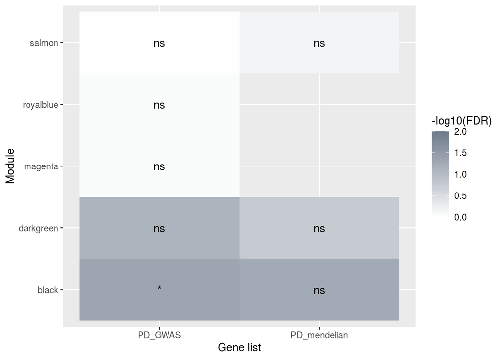

```r
# Filter repeats
MA_melt_summ <- MA_pvals_list %>%
  dplyr::distinct()
# Prep for figure
MA_melt_summ$Module <- as.character(MA_melt_summ$Module)
MA_melt_summ$Gene_list <- as.character(MA_melt_summ$Gene_list)
MA_melt_summ <- dplyr::arrange(MA_melt_summ, Module)
MA_melt_summ$`-log10(FDR)` <- -log10(MA_melt_summ$FDR)
# Plot
ggplot(MA_melt_summ, aes(Gene_list, Module)) +
  geom_tile(aes(fill = `-log10(FDR)`)) +
  geom_text(aes(label = signif.num(FDR))) +
  scale_fill_gradient(low = "white", high = "lightsteelblue4", limits = c(0,2)) +
  labs(y = "Module", x = "Gene list")
```

# 5. Microglia network

The overall structure of the network was first examined.

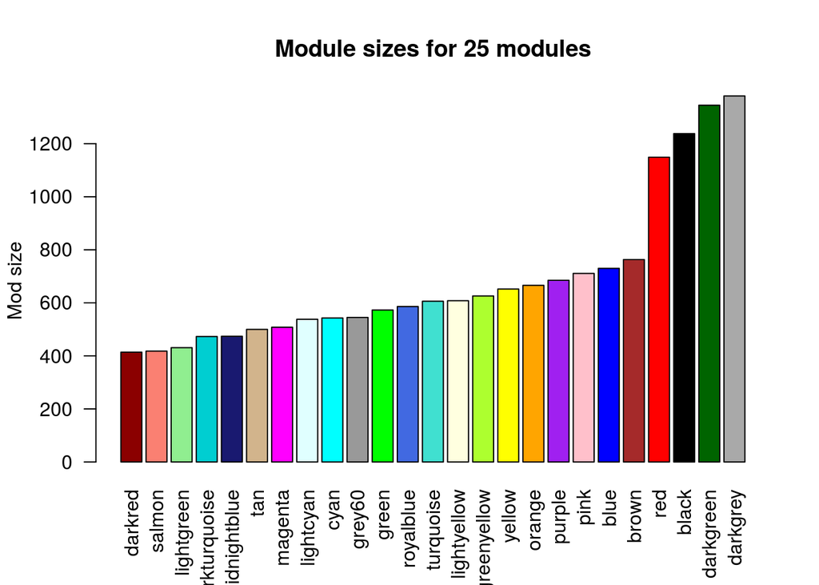

```r
# Load network
MG_net = readRDS(file.path(here::here("data", "Networks", "netFCTX.12.signed.it.20.rds.No.MG.rds")))
# Plot sizes of modules making up the network
CoExpNets::plotModSizes(tissue = MG_net, which.one = "new")
```

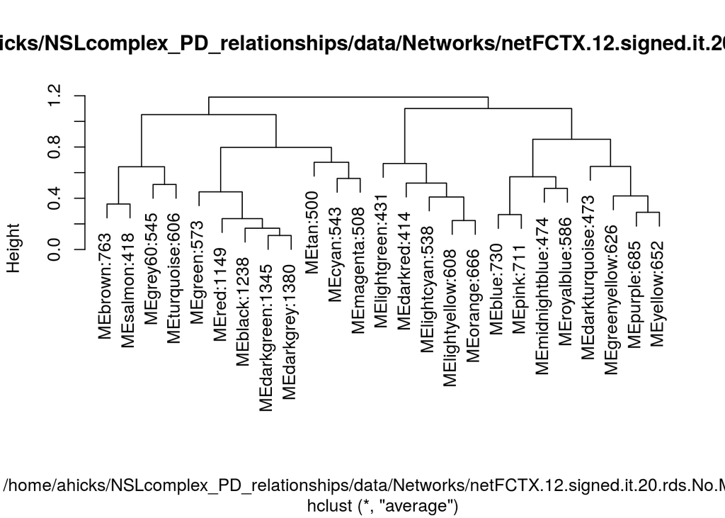

```r
# Obtain eigengenes for each module
MG_net.name <- file.path(here::here("data", "Networks", "netFCTX.12.signed.it.20.rds.No.MG.rds"))
MG_egs <- CoExpNets::getNetworkEigengenes(tissue = MG_net.name, which.one = "new")
# Plot eigengene clustering
CoExpNets::plotEGClustering(tissue = MG_net.name, which.one = "new")
```

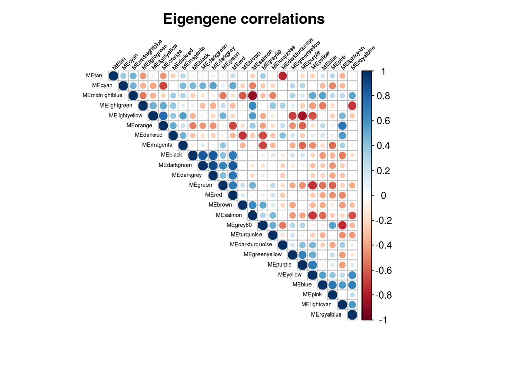

```r
# Plot correlation between modules
corrplot(cor(MG_egs), tl.srt = 45,
         tl.col = "black",
         type = "upper",
         tl.cex = 0.45,
         order = "hclust",
         title = paste0("Eigengene correlations"),
         mar = c(3, 2, 2.5, 4))
```

## 5.1. Searching gene lists

### NSL genes

```r
# Search genes in network
MG_NSL_mod <- as.data.frame(CoExpNets::reportOnFETGenes(tissue = MG_net.name, genes = NSL_ENSG, which.one = "new", net = NULL))
MG_NSL_mod <- tibble::rownames_to_column(MG_NSL_mod, "ENSG")
MG_NSL_mod <- dplyr::select(MG_NSL_mod, ENSG, module, p.val.mods)
MG_NSL_mod$Gene <- MG_NSL_mod$ENSG
# Add gene symbols
for (i in NSL_list$UKBEC_symbol) {
  loc <- match(i, NSL_list$UKBEC_symbol)
  MG_NSL_mod$Gene[MG_NSL_mod$Gene== i] <- NSL_list$Gene_symbol[loc]
}
# Get module membership
MG_MM <- as.data.frame(MG_net$MM)
colnames(MG_MM)<- "MM"
MG_MM <- rownames_to_column(MG_MM, "ENSG")
MG_MM$MM <- signif(MG_MM$MM, 4)
# Add MM to table
MG_NSL_mod$MM <- MG_NSL_mod$ENSG
for (i in MG_MM$ENSG) {
  loc <- match(i, MG_MM$ENSG)
  MG_NSL_mod$MM[MG_NSL_mod$MM== i] <- MG_MM$MM[loc]
}
# Reorder table
MG_NSL_mod <- MG_NSL_mod[,c(4,1,5,2,3)]
MG_NSL_mod <- dplyr::arrange(MG_NSL_mod, p.val.mods)
# Store NSL enriched modules
MG_NSL_modules <- as.character(unique(MG_NSL_mod$module))
MG_NSL_modules <- MG_NSL_modules[!MG_NSL_modules =="void"]
# Print result
MG_NSL_mod
```

| Gene | ENSG | MM | module | p.val.mods |
| --- | --- | --- | --- | --- |
| HCFC1 | ENSG00000172534 | 0.8248 | purple | 0.0001549 |
| KANSL1 | KIAA1267 | 0.7137 | purple | 0.0001549 |
| KAT8 | MYST1 | 0.4684 | purple | 0.0001549 |
| MCRS1 | ENSG00000187778 | 0.5222 | purple | 0.0001549 |
| KANSL3 | KIAA1310 | 0.4788 | darkturquoise | 0.2004 |
| OGT | ENSG00000147162 | 0.6912 | midnightblue | 0.2008 |
| KANSL2 | C12orf41 | 0.5197 | tan | 0.2107 |
| PHF20 | ENSG00000025293 | 0.8026 | pink | 0.2872 |
| WDR5 | ENSG00000196363 | ENSG00000196363 | void | 1 |

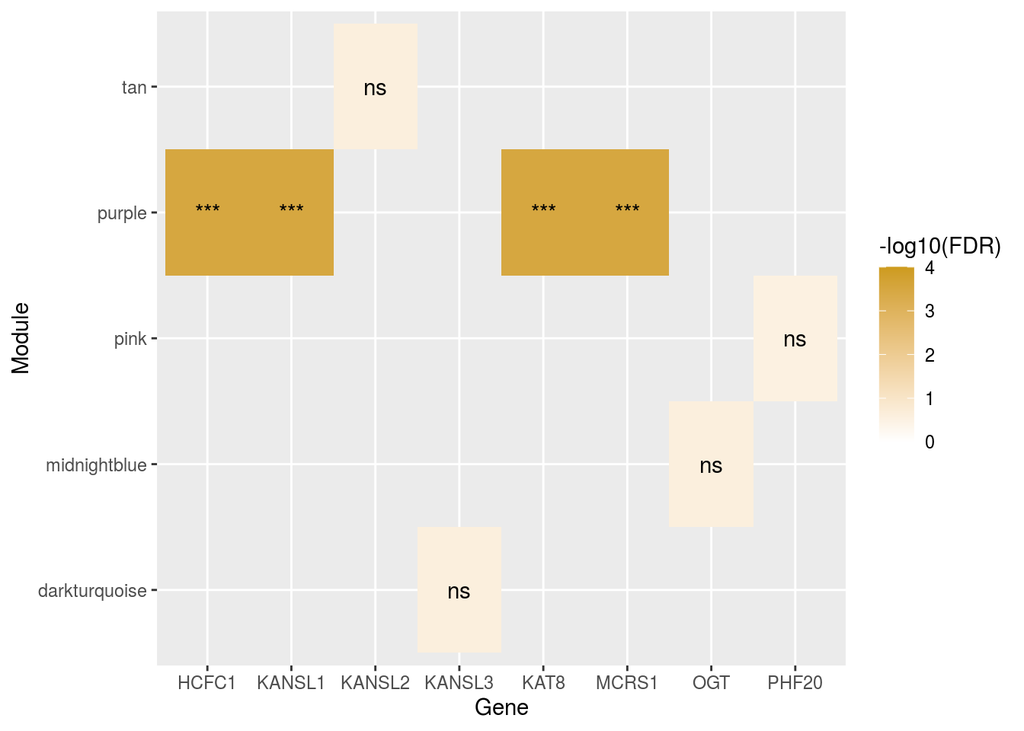

```r
# Remove void
MG_NSL_mod <- dplyr::filter(MG_NSL_mod, module !="void")
# Format dataframe for figure
MG_NSL_mod$FDR <- p.adjust(MG_NSL_mod$p.val.mods, method = "fdr")
names(MG_NSL_mod)[names(MG_NSL_mod)=="p.val.mods"] <- "p.val"
names(MG_NSL_mod)[names(MG_NSL_mod)=="module"] <- "Module"
MG_NSL_mod$p.val <- as.numeric(MG_NSL_mod$p.val)
MG_NSL_mod <- dplyr::arrange(MG_NSL_mod, Module)
MG_NSL_mod$`-log10(p.val)` <- -log10(MG_NSL_mod$p.val)
MG_NSL_mod$`-log10(FDR)` <- -log10(MG_NSL_mod$FDR)
# Produce plot
ggplot(MG_NSL_mod, aes(Gene, Module)) +
  geom_tile(aes(fill = `-log10(FDR)`)) +
  geom_text(aes(label = signif.num(FDR))) +
  scale_fill_gradient(low = "white", high = "goldenrod3", limits = c(0,4)) +
  labs(y = "Module", x = "Gene")
```

The number of genes in the output table was **8**, indicating there were **1** genes missing from the search. These genes appeared in 5 modules, each of which was examined for **enrichment** of cell type specific markers.

```r
# Load cell type markers enriched for each module
MG_mod_enrich <- as.data.frame(getModulesEnrichment(MG_net,
                                                    markers.path = file.path(here::here("data", "GMSCA_source", "markers"))))
# Filter enrichments for NSL modules
MG_mod_enrich_NSL <- dplyr::select(MG_mod_enrich, one_of(MG_NSL_modules))
```

The modules containing NSL genes showed **no significant enrichment** for **any cell types**.

### PD mendelian genes

The results tables for the mendelian PD gene list were filtered for the 5 modules containing NSL genes.

```r
# Search genes in network
MG_PD_mendelian_mod <- as.data.frame(CoExpNets::reportOnFETGenes(tissue = MG_net.name, genes = PD_mendelian_ENSG, which.one = "new", net = NULL))
MG_PD_mendelian_mod <- tibble::rownames_to_column(MG_PD_mendelian_mod, "ENSG")
MG_PD_mendelian_mod <- dplyr::select(MG_PD_mendelian_mod, ENSG, module, p.val.mods)
MG_PD_mendelian_mod$Gene <- MG_PD_mendelian_mod$ENSG
# Add gene symbols
for (i in PD_mendelian_list$UKBEC_symbol) {
  loc <- match(i, PD_mendelian_list$UKBEC_symbol)
  MG_PD_mendelian_mod$Gene[MG_PD_mendelian_mod$Gene== i] <- PD_mendelian_list$Gene_symbol[loc]
}
# Add MM to table
MG_PD_mendelian_mod$MM <- MG_PD_mendelian_mod$ENSG
for (i in MG_MM$ENSG) {
  loc <- match(i, MG_MM$ENSG)
  MG_PD_mendelian_mod$MM[MG_PD_mendelian_mod$MM== i] <- MG_MM$MM[loc]
}
# Reorder table
MG_PD_mendelian_mod <- MG_PD_mendelian_mod[,c(4,1,5,2,3)]
MG_PD_mendelian_mod <- dplyr::arrange(MG_PD_mendelian_mod, p.val.mods)
# Filter for NSL enriched modules
MG_PD_mendelian_mod1 <- filter(MG_PD_mendelian_mod, module %in% MG_NSL_modules)
# Print result
MG_PD_mendelian_mod1
```

| Gene | ENSG | MM | module | p.val.mods |
| --- | --- | --- | --- | --- |
| ATN1 | ENSG00000111676 | 0.7898 | purple | 0.0797 |
| ATXN2 | ENSG00000204842 | 0.7065 | purple | 0.0797 |
| GRN | ENSG00000030582 | 0.724 | purple | 0.0797 |
| TUBB4A | TUBB4 | 0.7618 | purple | 0.0797 |
| CSF1R | ENSG00000182578 | 0.3942 | darkturquoise | 0.1029 |
| DCTN1 | ENSG00000204843 | 0.6579 | darkturquoise | 0.1029 |
| TBP | ENSG00000112592 | 0.5134 | darkturquoise | 0.1029 |
| ATXN3 | ENSG00000066427 | 0.6767 | pink | 0.2405 |
| PANK2 | ENSG00000125779 | 0.5737 | pink | 0.2405 |
| PARK7 | ENSG00000116288 | 0.2624 | pink | 0.2405 |

[output cut: 1 more lines]

The number of genes in the output table was **43**, indicating there were **0** genes missing from the search.

### PD sporadic genes

The results tables for the sporadic PD gene list were filtered for the 5 modules containing NSL genes.

```r
# Search genes in network
MG_PD_GWAS_mod <- as.data.frame(CoExpNets::reportOnFETGenes(tissue = MG_net.name, genes = PD_GWAS_ENSG, which.one = "new", net = NULL))
MG_PD_GWAS_mod <- tibble::rownames_to_column(MG_PD_GWAS_mod, "ENSG")
MG_PD_GWAS_mod <- dplyr::select(MG_PD_GWAS_mod, ENSG, module, p.val.mods)
MG_PD_GWAS_mod$Gene <- MG_PD_GWAS_mod$ENSG
# Add gene symbols
for (i in PD_GWAS_list$UKBEC_symbol) {
  loc <- match(i, PD_GWAS_list$UKBEC_symbol)
  MG_PD_GWAS_mod$Gene[MG_PD_GWAS_mod$Gene== i] <- PD_GWAS_list$Gene_symbol[loc]
}
# Add MM to table
MG_PD_GWAS_mod$MM <- MG_PD_GWAS_mod$ENSG
for (i in MG_MM$ENSG) {
  loc <- match(i, MG_MM$ENSG)
  MG_PD_GWAS_mod$MM[MG_PD_GWAS_mod$MM== i] <- MG_MM$MM[loc]
}
# Reorder table
MG_PD_GWAS_mod <- MG_PD_GWAS_mod[,c(4,1,5,2,3)]
MG_PD_GWAS_mod <- dplyr::arrange(MG_PD_GWAS_mod, p.val.mods)
# Filter for NSL enriched modules
MG_PD_GWAS_mod1 <- filter(MG_PD_GWAS_mod, module %in% MG_NSL_modules)
# Print result
MG_PD_GWAS_mod1
```

| Gene | ENSG | MM | module | p.val.mods |
| --- | --- | --- | --- | --- |
| CCAR2 | ENSG00000158941 | 0.6074 | darkturquoise | 0.007773 |
| DALRD3 | ENSG00000178149 | 0.4616 | darkturquoise | 0.007773 |
| DPM3 | ENSG00000179085 | 0.4221 | darkturquoise | 0.007773 |
| FCGR2A | ENSG00000143226 | 0.3273 | darkturquoise | 0.007773 |
| GAK | ENSG00000178950 | 0.6116 | darkturquoise | 0.007773 |
| KCNIP3 | ENSG00000115041 | 0.5192 | darkturquoise | 0.007773 |
| NCKIPSD | ENSG00000213672 | 0.6827 | darkturquoise | 0.007773 |
| QRICH1 | ENSG00000198218 | 0.7096 | darkturquoise | 0.007773 |
| TMEM175 | ENSG00000127419 | 0.5476 | darkturquoise | 0.007773 |
| FBRSL1 | ENSG00000112787 | 0.7061 | purple | 0.1272 |

[output cut: 12 more lines]

The number of genes in the output table was **150**, indicating there were **0** genes missing from the search.

## 5.2. Summary

The **frequency** of **genes** within each gene **list** apppearing in each of the **5 NSL enriched modules** was calculated.

```r
knitr::kable(MG_mod_freq)
```

|  | PD_GWAS | PD_mendelian |
| --- | --- | --- |
| tan | 1 | 0 |
| pink | 2 | 3 |
| purple | 8 | 4 |
| midnightblue | 2 | 1 |
| darkturquoise | 9 | 3 |

The **significance** of the **enrichments** of each **gene list** within each of the **5 NSL enriched modules** was also calculated. P-values were **FDR-corrected** before summarising.

```r
# FDR correct p values
MG_PD_mendelian_mod1$FDR <- p.adjust(MG_PD_mendelian_mod1$p.val.mods, method = "fdr")
MG_PD_GWAS_mod1$FDR <- p.adjust(MG_PD_GWAS_mod1$p.val.mods, method = "fdr")
```

```r
knitr::kable(MG_TF)
```

|  | PD_GWAS | PD_mendelian |
| --- | --- | --- |
| tan | 0.9755000 | NA |
| pink | 0.9755000 | 0.26455 |
| purple | 0.1646118 | 0.16170 |
| midnightblue | 0.9755000 | 0.68330 |
| darkturquoise | 0.0190007 | 0.16170 |

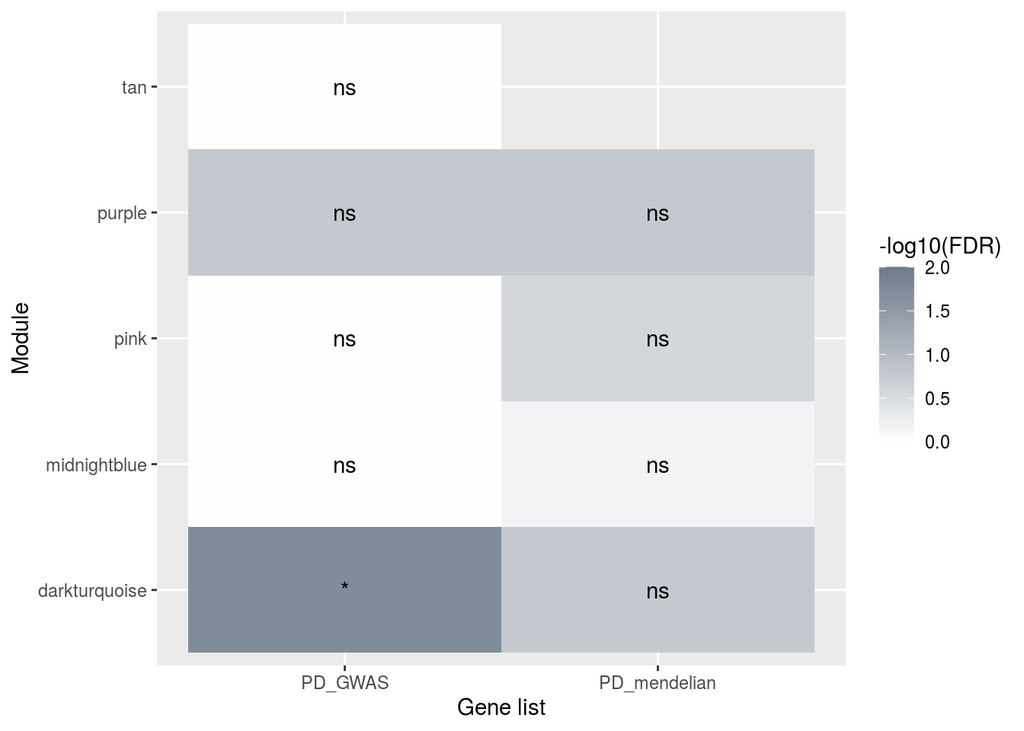

```r
# Filter repeats
MG_melt_summ <- MG_pvals_list %>%
  dplyr::distinct()
# Prep for figure
MG_melt_summ$Module <- as.character(MG_melt_summ$Module)
MG_melt_summ$Gene_list <- as.character(MG_melt_summ$Gene_list)
MG_melt_summ <- dplyr::arrange(MG_melt_summ, Module)
MG_melt_summ$`-log10(FDR)` <- -log10(MG_melt_summ$FDR)
# Plot
ggplot(MG_melt_summ, aes(Gene_list, Module)) +
  geom_tile(aes(fill = `-log10(FDR)`)) +
  geom_text(aes(label = signif.num(FDR))) +
  scale_fill_gradient(low = "white", high = "lightsteelblue4", limits = c(0,2)) +
  labs(y = "Module", x = "Gene list")
```

# 6. Oligodendrocyte network

The overall structure of the network was first examined.

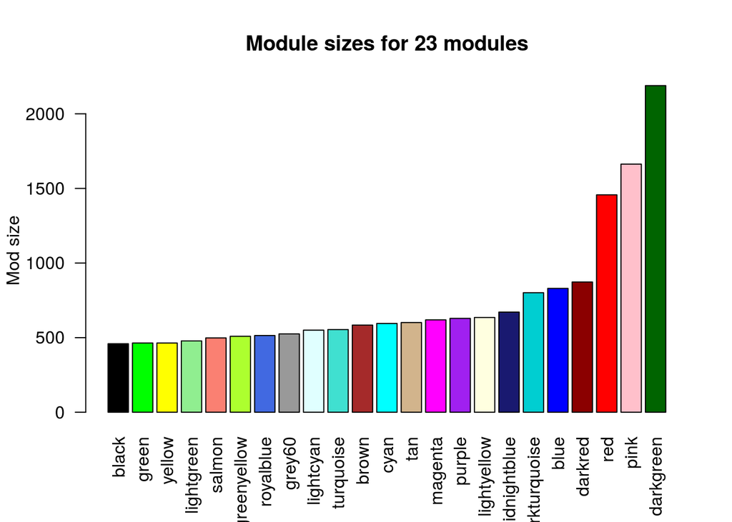

```r
# Load network
OLG_net = readRDS(file.path(here::here("data", "Networks", "netFCTX.12.signed.it.20.rds.No.OLG.rds")))
# Plot sizes of modules making up the network
CoExpNets::plotModSizes(tissue = OLG_net, which.one = "new")
```

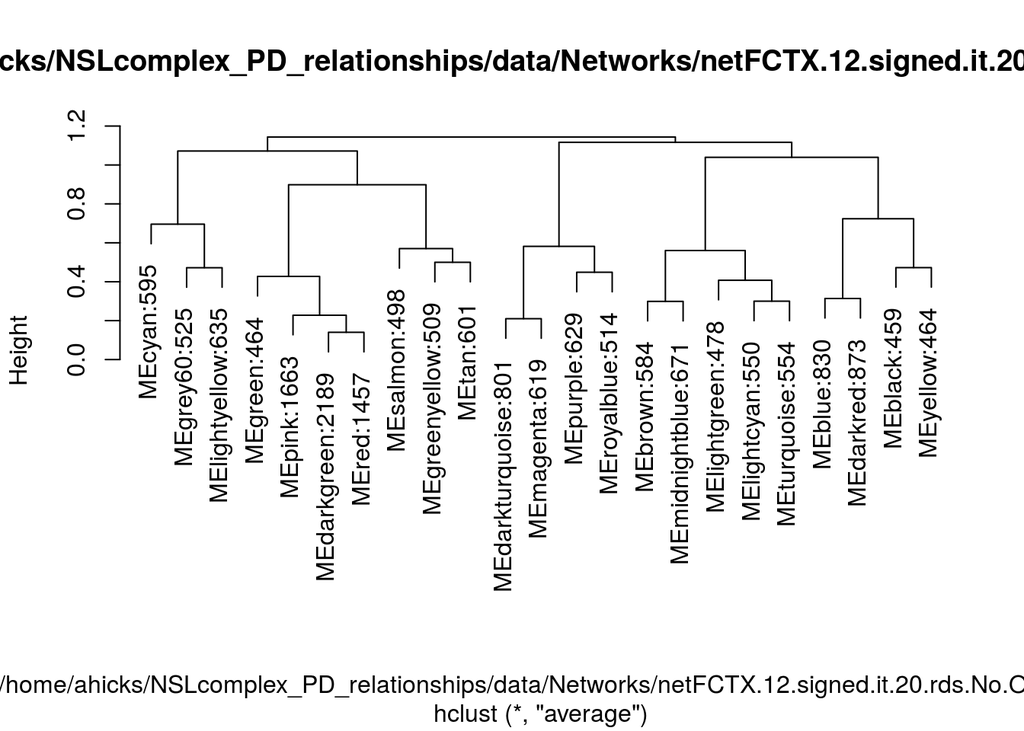

```r
# Obtain eigengenes for each module
OLG_net.name <- file.path(here::here("data", "Networks", "netFCTX.12.signed.it.20.rds.No.OLG.rds"))
OLG_egs <- CoExpNets::getNetworkEigengenes(tissue = OLG_net.name, which.one = "new")
# Plot eigengene clustering
CoExpNets::plotEGClustering(tissue = OLG_net.name, which.one = "new")
```

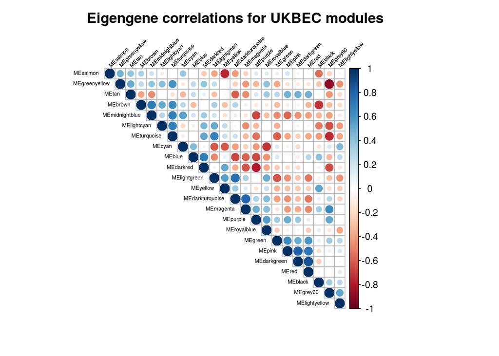

```r
# Plot correlation between modules
corrplot(cor(OLG_egs), tl.srt = 45,
         tl.col = "black",
         type = "upper",
         tl.cex = 0.45,
         order = "hclust",
         title = paste0("Eigengene correlations for UKBEC modules"),
         mar = c(3, 2, 2.5, 4))
```

## 6.1. Searching gene lists

### NSL genes

```r
# Search genes in network
OLG_NSL_mod <- as.data.frame(CoExpNets::reportOnFETGenes(tissue = OLG_net.name, genes = NSL_ENSG, which.one = "new", net = NULL))
OLG_NSL_mod <- tibble::rownames_to_column(OLG_NSL_mod, "ENSG")
OLG_NSL_mod <- dplyr::select(OLG_NSL_mod, ENSG, module, p.val.mods)
OLG_NSL_mod$Gene <- OLG_NSL_mod$ENSG
# Add gene symbols
for (i in NSL_list$UKBEC_symbol) {
  loc <- match(i, NSL_list$UKBEC_symbol)
  OLG_NSL_mod$Gene[OLG_NSL_mod$Gene== i] <- NSL_list$Gene_symbol[loc]
}
# Get module membership
OLG_MM <- as.data.frame(OLG_net$MM)
colnames(OLG_MM)<- "MM"
OLG_MM <- rownames_to_column(OLG_MM, "ENSG")
OLG_MM$MM <- signif(OLG_MM$MM, 4)
# Add MM to table
OLG_NSL_mod$MM <- OLG_NSL_mod$ENSG
for (i in OLG_MM$ENSG) {
  loc <- match(i, OLG_MM$ENSG)
  OLG_NSL_mod$MM[OLG_NSL_mod$MM== i] <- OLG_MM$MM[loc]
}
# Reorder table
OLG_NSL_mod <- OLG_NSL_mod[,c(4,1,5,2,3)]
OLG_NSL_mod <- dplyr::arrange(OLG_NSL_mod, p.val.mods)
# Store NSL enriched modules
OLG_NSL_modules <- as.character(unique(OLG_NSL_mod$module))
OLG_NSL_modules <- OLG_NSL_modules[!OLG_NSL_modules =="void"]
# Print result
OLG_NSL_mod
```

| Gene | ENSG | MM | module | p.val.mods |
| --- | --- | --- | --- | --- |
| HCFC1 | ENSG00000172534 | 0.8203 | darkred | 0.0003948 |
| KANSL1 | KIAA1267 | 0.6604 | darkred | 0.0003948 |
| KAT8 | MYST1 | 0.472 | darkred | 0.0003948 |
| MCRS1 | ENSG00000187778 | 0.5322 | darkred | 0.0003948 |
| KANSL3 | KIAA1310 | 0.4769 | black | 0.195 |
| KANSL2 | C12orf41 | 0.5305 | salmon | 0.2099 |
| OGT | ENSG00000147162 | 0.6801 | greenyellow | 0.2141 |
| PHF20 | ENSG00000025293 | 0.8048 | midnightblue | 0.2732 |
| WDR5 | ENSG00000196363 | ENSG00000196363 | void | 1 |

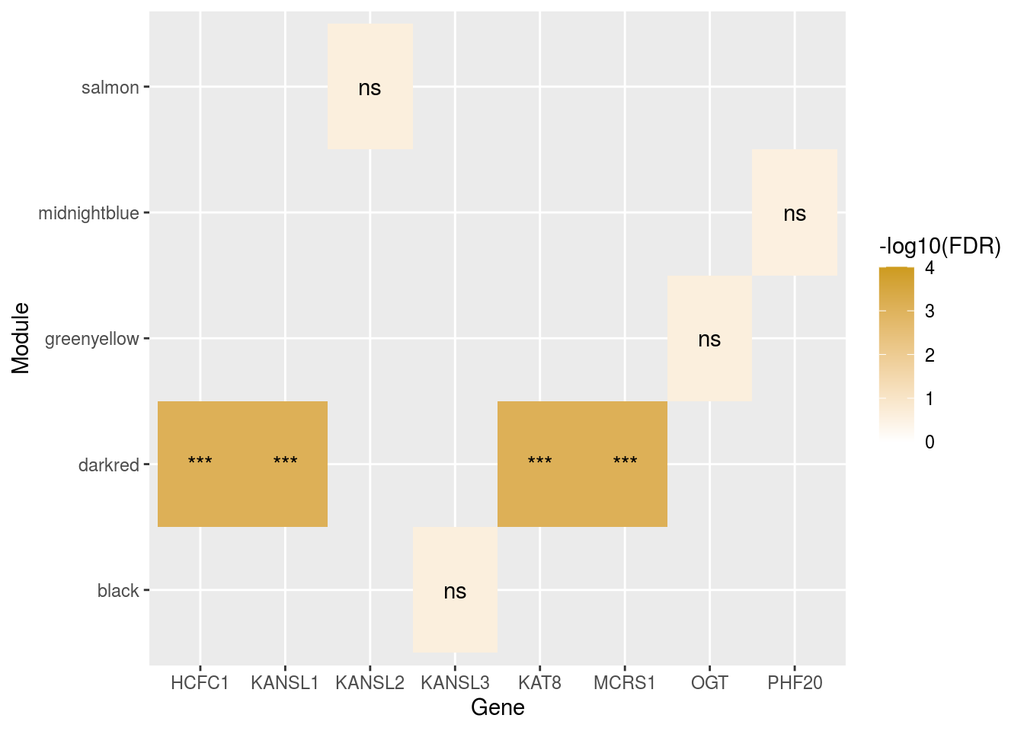

```r
# Remove void
OLG_NSL_mod <- dplyr::filter(OLG_NSL_mod, module !="void")
# Format dataframe for figure
OLG_NSL_mod$FDR <- p.adjust(OLG_NSL_mod$p.val.mods, method = "fdr")
names(OLG_NSL_mod)[names(OLG_NSL_mod)=="p.val.mods"] <- "p.val"
names(OLG_NSL_mod)[names(OLG_NSL_mod)=="module"] <- "Module"
OLG_NSL_mod$p.val <- as.numeric(OLG_NSL_mod$p.val)
OLG_NSL_mod <- dplyr::arrange(OLG_NSL_mod, Module)
OLG_NSL_mod$`-log10(p.val)` <- -log10(OLG_NSL_mod$p.val)
OLG_NSL_mod$`-log10(FDR)` <- -log10(OLG_NSL_mod$FDR)
# Produce plot
ggplot(OLG_NSL_mod, aes(Gene, Module)) +
  geom_tile(aes(fill = `-log10(FDR)`)) +
  geom_text(aes(label = signif.num(FDR))) +
  scale_fill_gradient(low = "white", high = "goldenrod3", limits = c(0,4)) +
  labs(y = "Module", x = "Gene")
```

The number of genes in the output table was **8**, indicating there were **1** genes missing from the search. These genes appeared in 5 modules, each of which was examined for **enrichment** of cell type specific markers.

```r
# Load cell type markers enriched for each module
OLG_mod_enrich <- as.data.frame(getModulesEnrichment(OLG_net,
                                                     markers.path = file.path(here::here("data", "GMSCA_source", "markers"))))
# Filter enrichments for NSL modules
OLG_mod_enrich_NSL <- dplyr::select(OLG_mod_enrich, one_of(OLG_NSL_modules))
```

The modules containing NSL genes showed **one significant enrichment** for a **neuronal cell type**.

### PD mendelian genes

```r
# Search genes in network
OLG_PD_mendelian_mod <- as.data.frame(CoExpNets::reportOnFETGenes(tissue = OLG_net.name, genes = PD_mendelian_ENSG, which.one = "new", net = NULL))
OLG_PD_mendelian_mod <- tibble::rownames_to_column(OLG_PD_mendelian_mod, "ENSG")
OLG_PD_mendelian_mod <- dplyr::select(OLG_PD_mendelian_mod, ENSG, module, p.val.mods)
OLG_PD_mendelian_mod$Gene <- OLG_PD_mendelian_mod$ENSG
# Add gene symbols
for (i in PD_mendelian_list$UKBEC_symbol) {
  loc <- match(i, PD_mendelian_list$UKBEC_symbol)
  OLG_PD_mendelian_mod$Gene[OLG_PD_mendelian_mod$Gene== i] <- PD_mendelian_list$Gene_symbol[loc]
}
# Add MM to table
OLG_PD_mendelian_mod$MM <- OLG_PD_mendelian_mod$ENSG
for (i in OLG_MM$ENSG) {
  loc <- match(i, OLG_MM$ENSG)
  OLG_PD_mendelian_mod$MM[OLG_PD_mendelian_mod$MM== i] <- OLG_MM$MM[loc]
}
# Reorder table
OLG_PD_mendelian_mod <- OLG_PD_mendelian_mod[,c(4,1,5,2,3)]
OLG_PD_mendelian_mod <- dplyr::arrange(OLG_PD_mendelian_mod, p.val.mods)
# Filter for NSL enriched modules
OLG_PD_mendelian_mod1 <- filter(OLG_PD_mendelian_mod, module %in% OLG_NSL_modules)
# Print result
OLG_PD_mendelian_mod1
```

| Gene | ENSG | MM | module | p.val.mods |
| --- | --- | --- | --- | --- |
| ATN1 | ENSG00000111676 | 0.779 | darkred | 0.01671 |
| ATXN2 | ENSG00000204842 | 0.6557 | darkred | 0.01671 |
| C19orf12 | ENSG00000131943 | 0.3356 | darkred | 0.01671 |
| GRN | ENSG00000030582 | 0.6464 | darkred | 0.01671 |
| OPA3 | ENSG00000125741 | 0.5484 | darkred | 0.01671 |
| TUBB4A | TUBB4 | 0.8174 | darkred | 0.01671 |
| ATXN3 | ENSG00000066427 | 0.6908 | midnightblue | 0.07511 |
| PANK2 | ENSG00000125779 | 0.5923 | midnightblue | 0.07511 |
| PARK7 | ENSG00000116288 | 0.2423 | midnightblue | 0.07511 |
| VPS13A | ENSG00000197969 | 0.752 | midnightblue | 0.07511 |

[output cut: 3 more lines]

The number of genes in the output table was **43**, indicating there were **0** genes missing from the search.

### PD sporadic genes

```r
# Search genes in network
OLG_PD_GWAS_mod <- as.data.frame(CoExpNets::reportOnFETGenes(tissue = OLG_net.name, genes = PD_GWAS_ENSG, which.one = "new", net = NULL))
OLG_PD_GWAS_mod <- tibble::rownames_to_column(OLG_PD_GWAS_mod, "ENSG")
OLG_PD_GWAS_mod <- dplyr::select(OLG_PD_GWAS_mod, ENSG, module, p.val.mods)
OLG_PD_GWAS_mod$Gene <- OLG_PD_GWAS_mod$ENSG
# Add gene symbols
for (i in PD_GWAS_list$UKBEC_symbol) {
  loc <- match(i, PD_GWAS_list$UKBEC_symbol)
  OLG_PD_GWAS_mod$Gene[OLG_PD_GWAS_mod$Gene== i] <- PD_GWAS_list$Gene_symbol[loc]
}
# Add MM to table
OLG_PD_GWAS_mod$MM <- OLG_PD_GWAS_mod$ENSG
for (i in OLG_MM$ENSG) {
  loc <- match(i, OLG_MM$ENSG)
  OLG_PD_GWAS_mod$MM[OLG_PD_GWAS_mod$MM== i] <- OLG_MM$MM[loc]
}
# Reorder table
OLG_PD_GWAS_mod <- OLG_PD_GWAS_mod[,c(4,1,5,2,3)]
OLG_PD_GWAS_mod <- dplyr::arrange(OLG_PD_GWAS_mod, p.val.mods)
# Filter for NSL enriched modules
OLG_PD_GWAS_mod1 <- filter(OLG_PD_GWAS_mod, module %in% OLG_NSL_modules)
# Print result
OLG_PD_GWAS_mod1
```

| Gene | ENSG | MM | module | p.val.mods |
| --- | --- | --- | --- | --- |
| GRN | ENSG00000030582 | 0.6464 | darkred | 0.02545 |
| HSD17B1 | ENSG00000108786 | 0.2991 | darkred | 0.02545 |
| PGS1 | ENSG00000087157 | 0.4607 | darkred | 0.02545 |
| POLR2A | ENSG00000181222 | 0.5029 | darkred | 0.02545 |
| PRSS3 | ENSG00000010438 | 0.6157 | darkred | 0.02545 |
| RETREG3 | ENSG00000141699 | 0.4936 | darkred | 0.02545 |
| SGF29 | ENSG00000176476 | 0.3043 | darkred | 0.02545 |
| SH2B1 | ENSG00000178188 | 0.7275 | darkred | 0.02545 |
| SPNS1 | ENSG00000169682 | 0.6087 | darkred | 0.02545 |
| STX1B | ENSG00000099365 | 0.7526 | darkred | 0.02545 |

[output cut: 11 more lines]

The number of genes in the output table was **150**, indicating there were **0** genes missing from the search.

## 6.2. Summary

The **frequency** of **genes** within each gene **list** apppearing in each of the **5 NSL enriched modules** was calculated.

```r
# Collate module results into one table
OLG1 <- OLG_PD_mendelian_mod1['module']
OLG1['Gene_list'] <- "PD_mendelian"
OLG2 <- OLG_PD_GWAS_mod1['module']
OLG2['Gene_list'] <- "PD_GWAS"
OLG_mods_list <- do.call(rbind, list(OLG1, OLG2))
# Display as frequency of each module within each list
OLG_mod_freq <- with(OLG_mods_list, table(module, Gene_list))
OLG_mod_freq <- as.data.frame.matrix(OLG_mod_freq)
OLG_mod_freq <- dplyr::filter(OLG_mod_freq, rownames(OLG_mod_freq) %in% OLG_NSL_modules)
OLG_mod_freq <- OLG_mod_freq[c(2, 1, 4, 5, 3),]
```

```r
knitr::kable(OLG_mod_freq)
```

|  | PD_GWAS | PD_mendelian |
| --- | --- | --- |
| darkred | 12 | 6 |
| black | 3 | 2 |
| midnightblue | 2 | 4 |
| salmon | 1 | 0 |
| greenyellow | 3 | 1 |

The **significance** of the **enrichments** of each **gene list** within each of the **5 NSL enriched modules** was also calculated. P-values were **FDR-corrected** before summarising.

```r
# FDR correct p values
OLG_PD_mendelian_mod1$FDR <- p.adjust(OLG_PD_mendelian_mod1$p.val.mods, method = "fdr")
OLG_PD_GWAS_mod1$FDR <- p.adjust(OLG_PD_GWAS_mod1$p.val.mods, method = "fdr")
```

```r
# Collate module results into one table
OLGs1 <- data.frame(OLG_PD_mendelian_mod1$module, OLG_PD_mendelian_mod1$FDR)
names(OLGs1)[names(OLGs1)=="OLG_PD_mendelian_mod1.FDR"] <- "FDR"
names(OLGs1)[names(OLGs1)=="OLG_PD_mendelian_mod1.module"] <- "Module"
OLGs1$Gene_list <- "PD_mendelian"
OLGs2 <- data.frame(OLG_PD_GWAS_mod1$module, OLG_PD_GWAS_mod1$FDR)
names(OLGs2)[names(OLGs2)=="OLG_PD_GWAS_mod1.FDR"] <- "FDR"
names(OLGs2)[names(OLGs2)=="OLG_PD_GWAS_mod1.module"] <- "Module"
OLGs2$Gene_list <- "PD_GWAS"
OLG_pvals_list <- dplyr::bind_rows(OLGs1, OLGs2)
# Display as true/false table
OLG_TF <- OLG_pvals_list %>%
  dplyr::distinct() %>%
  tidyr::spread(Gene_list, FDR)
OLG_TF <- tibble::column_to_rownames(OLG_TF, var = "Module")
OLG_TF <- OLG_TF[c(2, 1, 5, 3, 4), ]
```

```r
knitr::kable(OLG_TF)
```

|  | PD_GWAS | PD_mendelian |
| --- | --- | --- |
| darkred | 0.0445375 | 0.0362050 |
| black | 0.8414000 | 0.3252167 |
| salmon | 0.9751000 | NA |
| greenyellow | 0.8414000 | 0.7094000 |
| midnightblue | 0.9751000 | 0.0976430 |

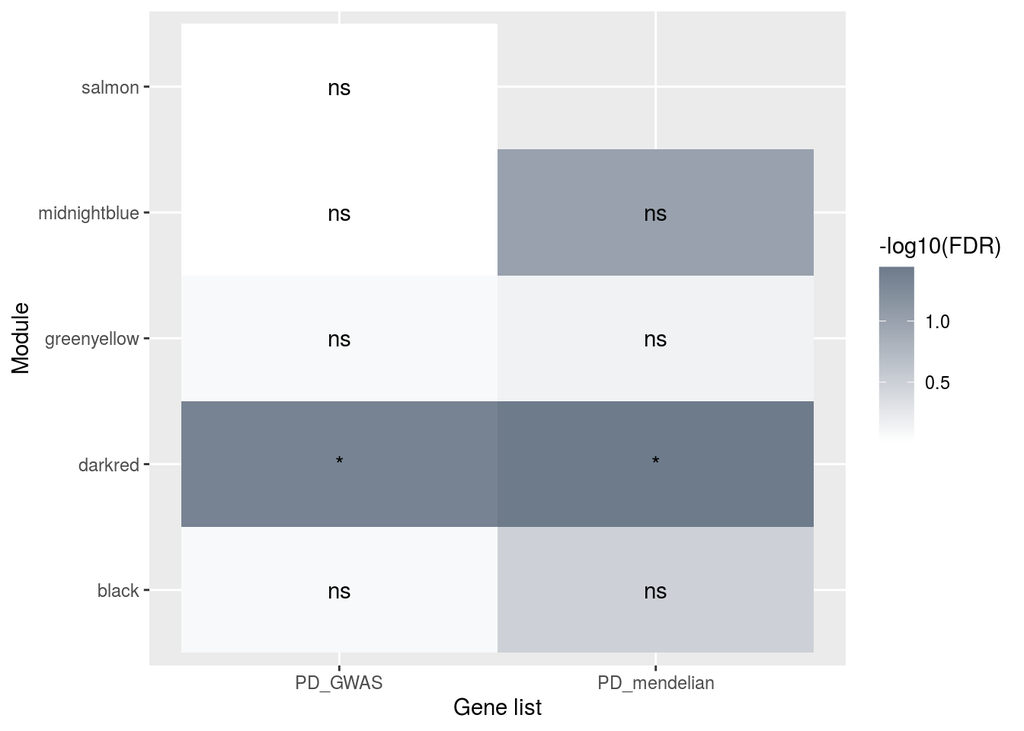

```r
# Filter repeats
OLG_melt_summ <- OLG_pvals_list %>%
  dplyr::distinct()
# Prep for figure
OLG_melt_summ$Module <- as.character(OLG_melt_summ$Module)
OLG_melt_summ$Gene_list <- as.character(OLG_melt_summ$Gene_list)
OLG_melt_summ <- dplyr::arrange(OLG_melt_summ, Module)
OLG_melt_summ$`-log10(FDR)` <- -log10(OLG_melt_summ$FDR)
# Plot
ggplot(OLG_melt_summ, aes(Gene_list, Module)) +
  geom_tile(aes(fill = `-log10(FDR)`)) +
  geom_text(aes(label = signif.num(FDR))) +
  scale_fill_gradient(low = "white", high = "lightsteelblue4") +
  labs(y = "Module", x = "Gene list")
```

# 7. Overall summary

First, the overall clustering of the NSL genes was examined

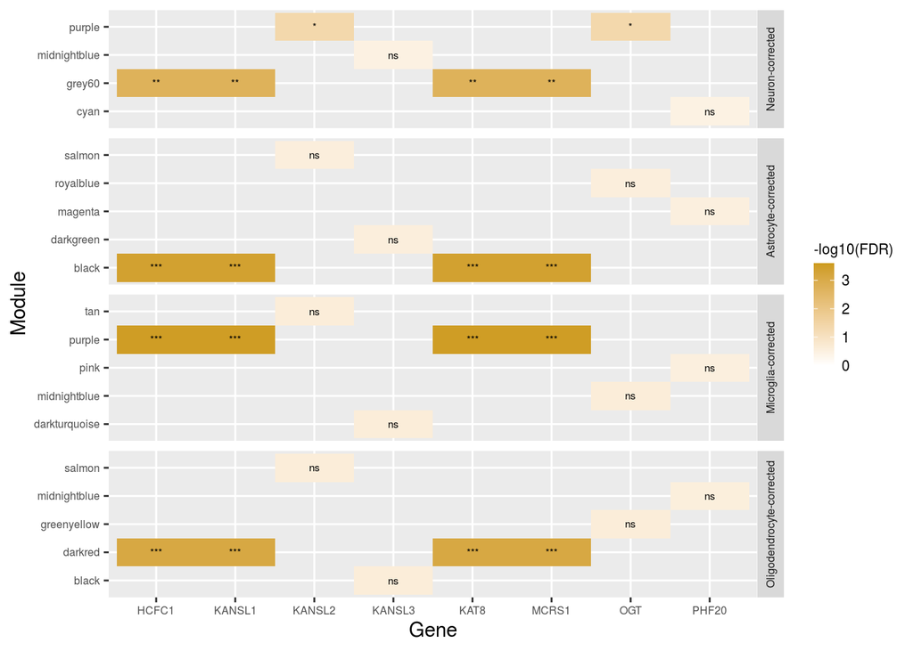

```r
N_NSL_mod$Network <- "Neuron-corrected"
MA_NSL_mod$Network <- "Astrocyte-corrected"
MG_NSL_mod$Network <- "Microglia-corrected"
OLG_NSL_mod$Network <- "Oligodendrocyte-corrected"
NSL_fig <- do.call(rbind, list(N_NSL_mod[,c(1,2,4,5,6,7,8,9)],
                               MA_NSL_mod,
                               MG_NSL_mod[,c(1,2,4,5,6,7,8,9)],
                               OLG_NSL_mod[,c(1,2,4,5,6,7,8,9)]))
NSL_fig <- dplyr::select(NSL_fig, Gene, Module, FDR, `-log10(FDR)`, Network)
# Produce plot
ggplot(NSL_fig, aes(Gene, Module)) +
  geom_tile(aes(fill = `-log10(FDR)`)) +
  geom_text(aes(label = signif.num(FDR)), size = 2) +
  scale_fill_gradient(low = "white", high = "goldenrod3", limits = c(0,3.6)) +
  labs(y = "Module", size = 4) +
  facet_grid(factor(Network,
                    levels = c("Neuron-corrected",
                               "Astrocyte-corrected",
                               "Microglia-corrected",
                               "Oligodendrocyte-corrected")) ~ .,
             scales = "free", space = "free") +
  theme(strip.text.y = element_text(angle = 90, size = 6),
        axis.text = element_text(size = 6),
        legend.title = element_text(size = 8),
        legend.text = element_text(size = 8),
        legend.key.size = unit(4, "mm"))
```

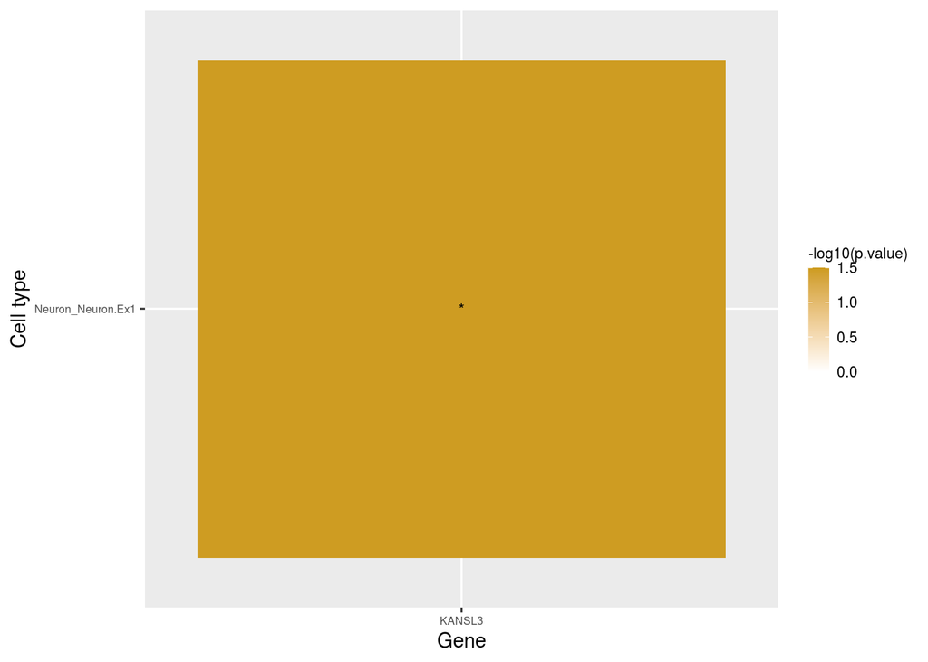

```r
# Format cell type enrichment tables (N not included as no cell type enrichments in NSL modules)
MA_mod_enrich_fig <- MA_mod_enrich_NSL %>%
  dplyr::filter_all(any_vars(.<0.05))
MA_mod_enrich_fig <- as.data.frame(t(MA_mod_enrich_fig)) %>%
  rownames_to_column(var = "Module")
MG_mod_enrich_fig <- MG_mod_enrich_NSL %>%
  dplyr::filter_all(any_vars(.<0.05))
MG_mod_enrich_fig <- as.data.frame(t(MG_mod_enrich_fig)) %>%
  rownames_to_column(var = "Module")
OLG_mod_enrich_fig <- OLG_mod_enrich_NSL %>%
  dplyr::filter_all(any_vars(.<0.05))
OLG_mod_enrich_fig <- as.data.frame(t(OLG_mod_enrich_fig)) %>%
  rownames_to_column(var = "Module")
ukbec_enrich_fig <- ukbec_enrich_NSL %>%
  dplyr::filter_all(any_vars(.<0.05))
ukbec_enrich_fig <- as.data.frame(t(ukbec_enrich_fig)) %>%
  rownames_to_column(var = "Module")
# Format NSL gene enrichment tables
N_NSL_fig <- dplyr::select(N_NSL_mod, Gene, Module)
N_NSL_fig$Network <- "Neuron-corrected"
MA_NSL_fig <- dplyr::select(MA_NSL_mod, Gene, Module)
MA_NSL_fig$Network <- "Astrocyte-corrected"
MG_NSL_fig <- dplyr::select(MG_NSL_mod, Gene, Module)
MG_NSL_fig$Network <- "Microglia-corrected"
OLG_NSL_fig <- dplyr::select(OLG_NSL_mod, Gene, Module)
OLG_NSL_fig$Network <- "Oligodendrocyte-corrected"
ukbec_NSL_fig <- dplyr::select(NSL_rep_uk, gene, module)
names(ukbec_NSL_fig)[names(ukbec_NSL_fig)=="module"] <- "Module"
names(ukbec_NSL_fig)[names(ukbec_NSL_fig)== "gene"] <- "Gene"
ukbec_NSL_fig$Network <- "None"
# Only one enrichment so can't join together
OLG_NSL_figure <- dplyr::full_join(OLG_mod_enrich_fig, OLG_NSL_fig, by = "Module")
OLG_NSL_figure <- dplyr::filter_all(OLG_NSL_figure, any_vars(.<1))
# Reformat and add -log10 values
OLG_NSL_figure$`-log10(p.value)` <- -log10(OLG_NSL_figure$Neuron_Neuron.Ex1)
OLG_NSL_figure$`-log10(p.value)` <- as.numeric(OLG_NSL_figure$`-log10(p.value)`)
names(OLG_NSL_figure)[names(OLG_NSL_figure)=="Neuron_Neuron.Ex1"] <- "Enrichment"
OLG_NSL_figure$Cell_type <- "Neuron_Neuron.Ex1"
# Round pvalue just for presentation purposes
OLG_NSL_figure$`-log10(p.value)` <- signif(OLG_NSL_figure$`-log10(p.value)`, digits = 3)
# Produce plot
ggplot(OLG_NSL_figure, aes(Gene, Cell_type)) +
  geom_tile(aes(fill = `-log10(p.value)`)) +
  geom_text(aes(label = signif.num2(Enrichment)), size = 3) +
  scale_fill_gradient(low = "white", high = "goldenrod3", limits = c(0,1.5)) +
  labs(y = "Cell type") +
  theme(
    strip.text.y = element_text(angle = 90, size = 6),
    axis.text = element_text(size = 6),
    legend.title = element_text(size = 8),
    legend.text = element_text(size = 8),
    legend.key.size = unit(4, "mm"))
```